# Mini-Project-2

Shivani, Sharan, Ajinkya, Anuhya

11/7/2021

## Obama To Trump

**Team members: Ajinkya Pawale , Sharanbasav sumbad ,Shivani Vogiral , Anuhya Sankranti**

Importing the required libraries and Loading the data

```r
knitr::opts_chunk$set(echo = TRUE, warning = FALSE, message = FALSE)
library(tidyverse)
cb_palette = c("#999999", "#E69F00", "#56B4E9", "#009E73",
"#F0E442", "#0072B2", "#D55E00", "#CC79A7")
library(stringr)
library(reshape2)
library(ggplot2)
library(MASS)
library(jpeg)
library(RCurl)
library(grid)
library(png)
library(GGally)
library(dplyr)
library(mgcv)
```

```r
cbbPalette <- c("#000000", "#E69F00", "#56B4E9", "#009E73", "#F0E442", "#0072B2", "#D55E00", "#CC79A7")
load('CCES16_Common_OUTPUT_Feb2018_VV.RData')
data=x
```

```r
remove(x)
```

```r
lis = c('commonweight_vv_post','tookpost','gender','educ','race','pid7','CC16_326','CC16_410a','CC16_331_1','CC16_331_2','CC16_331_3','CC16_331_7')
data = data[,lis]
```

### Question 1

Data Preprocessing and making a data frame called Obama with necessary conditions mentioned in Question one

```r
obama = filter(data, tookpost == 'Yes' & CC16_326=="Barack Obama")
obama$isTrump[obama$CC16_410a == 'Donald Trump (Republican)'] = 1
obama$isTrump[obama$CC16_410a != 'Donald Trump (Republican)'] = 0
obama$isTrump[is.na(obama$isTrump)] = 0
```

Function to create a quantitative variable that measures the respondent’s attitude toward immigration using the four immigration variables from the columns CC16_331_1, CC16_331_2, CC16 331_3, CC16_33_7 called pro.img (immigration attitude).

```r
obama$pro.img = 0
for (i in 1:nrow(obama))
{
if (obama$CC16_331_1[i] == 'Yes')
{
  obama$pro.img[i] = obama$pro.img[i]  + 1

}
if (obama$CC16_331_2[i]  == 'No')
{
  obama$pro.img[i] = obama$pro.img[i] + 1
}
if (obama$CC16_331_3[i] == 'Yes')
{
  obama$pro.img[i] = obama$pro.img[i]  + 1
}
if (obama$CC16_331_7[i]  == 'No')
{
  obama$pro.img[i]  = obama$pro.img[i]  + 1
}
}
```

Re-coding the race, education , party interaction and gender to required categories and then to numerical varaibles

```r
obama = obama %>% mutate(race=recode(race, 'White' = 'White','Black' = 'Black','Hispanic'='Hispanic',.default = "Other"))
obama = obama %>% mutate(educ_num=recode(educ, 'No HS' = 1, 'High school graduate' = 2,'Some college'=3,'2-year'=4,'4-year'=5,'Post-grad'=6))
obama = obama %>% mutate(pid7_num=recode(pid7, 'Strong Democrat' = 1, 'Not very strong Democrat' = 2,'Strong Republican'=7,'Not very strong Republican'=6,'Lean Democrat'=3,'Lean Republican'=5,'Independent'=4,'Not Sure'=8,.default = 0))
obama = obama %>% mutate(gender_num = recode(gender,'Male'=0,'Female'=1))
obama = obama %>% mutate(race_num = recode(race,'White'=0,'Black'=1,'Hispanic'=2,'Other'=3))
```

Initial analysis of the the varaibles with each other and the target varaible

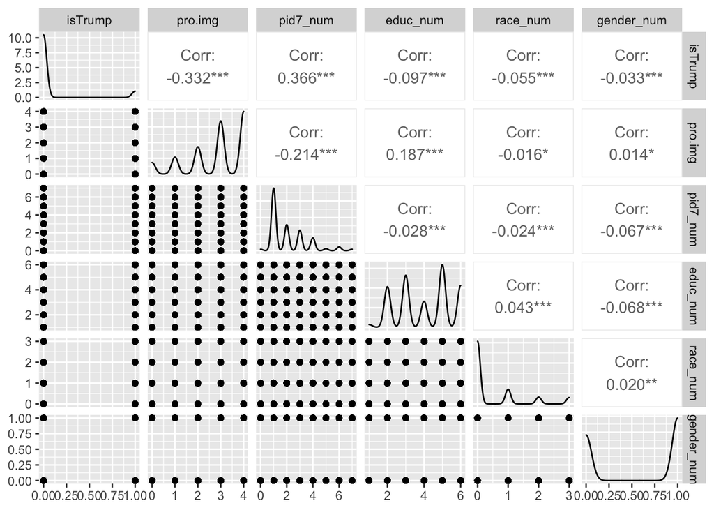

```r
lis = c('isTrump','pro.img','pid7_num','educ_num','race_num','gender_num')
ggpairs(obama[,lis])
```

### Question 2

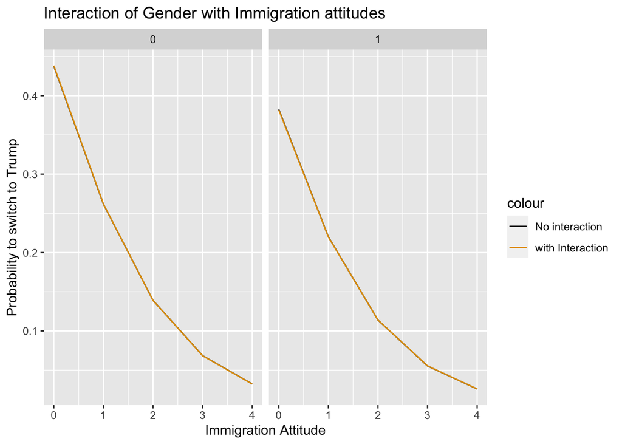

```r
#1. With No interactions for Gender demographic variable
gender.logit=glm(isTrump~ pro.img  + gender_num,family="binomial",data=obama,weights = obama$commonweight_vv_post)
gender.df=expand.grid(pro.img=0:4,gender_num=c(0,1))
gender.nointer.pred=predict(gender.logit,newdata = gender.df,type = "response")
gender.nointer.pred=as.vector((gender.nointer.pred))

#2. With interaction for Gender demographic variable
gender.logit.inter=glm(isTrump~pro.img*gender_num,family = "binomial",data=obama,weights = obama$commonweight_vv_post)
gender.inter.pred=predict(gender.logit.inter,type = "response",newdata = gender.df)
gender.inter.pred=as.vector((gender.inter.pred))

gender.pred.df=data.frame(gender.df,gender.nointer.pred,gender.inter.pred)
ggplot(gender.pred.df,aes(x=gender.pred.df$pro.img))+geom_line(aes(y=gender.pred.df$gender.nointer.pred,color="No interaction"))+geom_line(aes(y=gender.pred.df$gender.inter.pred,color="with Interaction"))+facet_wrap(~gender.pred.df$gender_num)+ylab("Probability to switch to Trump")+xlab("Immigration Attitude")+ggtitle("Interaction of Gender with Immigration attitudes") + scale_colour_manual(values=cbPalette)
```

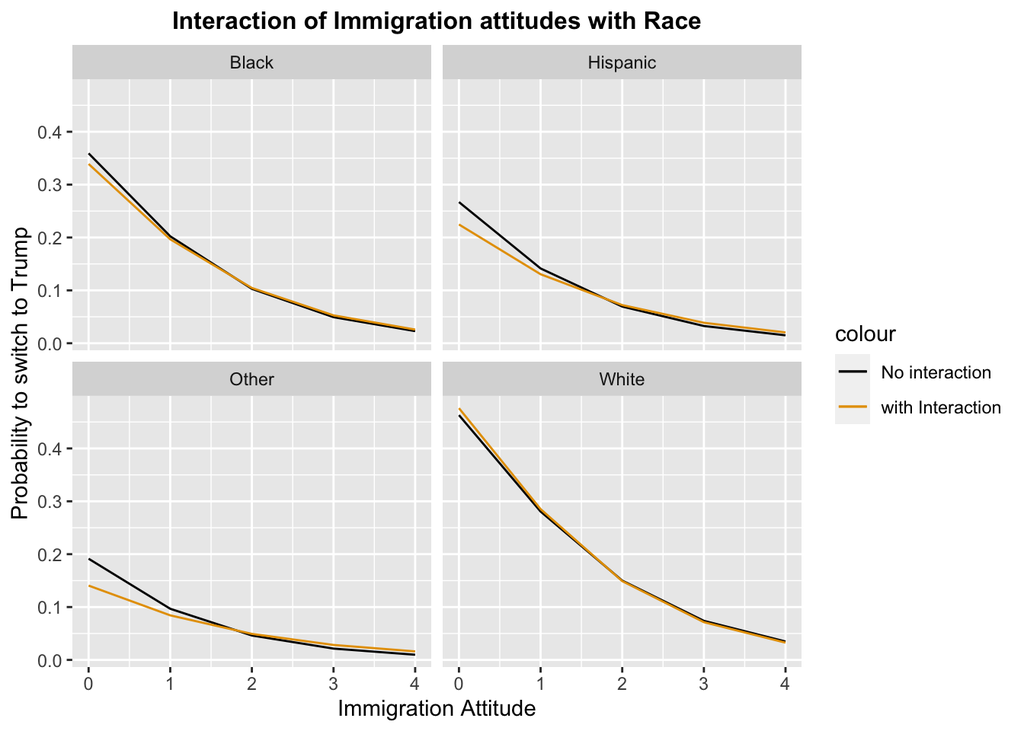

```r
#Implementing for race
#1. With No interactions for Race demographic variable

race.logit=glm(isTrump~ pro.img + race_num ,family="binomial",data=obama,weights = obama$commonweight_vv_post)
race.df=expand.grid(pro.img=0:4,race_num=c(0,1,2,3))
race.nointer.pred=predict(race.logit,newdata = race.df,type = "response")
race.nointer.pred=as.vector((race.nointer.pred))

#2. With interaction for Race demographic variable
race.logit.inter=glm(isTrump~pro.img*race_num,family = "binomial",data=obama,weights = obama$commonweight_vv_post)
race.inter.pred=predict(race.logit.inter,type = "response",newdata = race.df)
race.inter.pred=as.vector((race.inter.pred))
#Forming a new data frame
race.pred.df=data.frame(race.df,race.nointer.pred,race.inter.pred)

race.pred.df = race.pred.df %>% mutate(race = recode(race_num,'0'='White', '1'='Black','2'='Hispanic', '3'='Other'))

#Ggplot
ggplot(race.pred.df,aes(x=race.pred.df$pro.img))+geom_line(aes(y=race.pred.df$race.nointer.pred,color="No interaction"))+geom_line(aes(y=race.pred.df$race.inter.pred,color="with Interaction"))+facet_wrap(~race.pred.df$race)+ylab("Probability to switch to Trump")+xlab("Immigration Attitude")+ggtitle("Interaction of Immigration attitudes with Race") + theme(plot.title = element_text(size = 12, face = "bold", hjust = 0.5)) + scale_colour_manual(values=cbPalette)
```

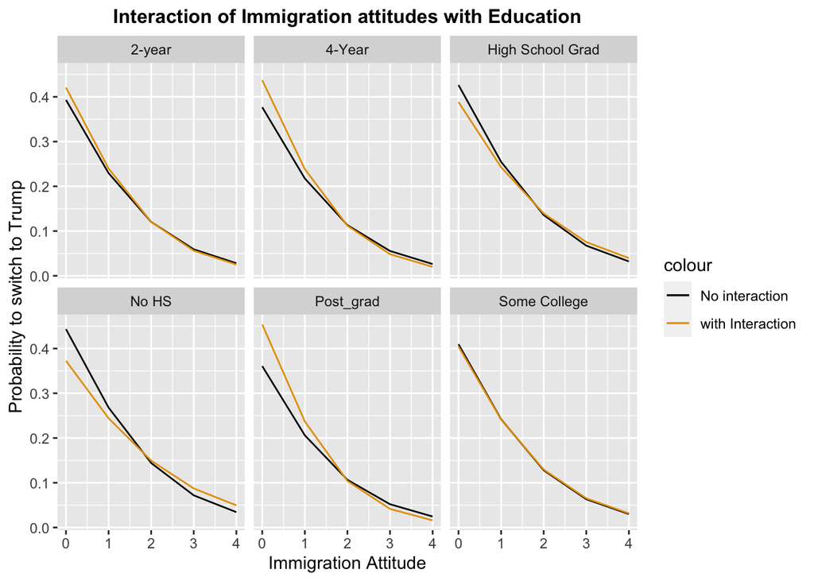

```r
#For Education
#1. With No interactions for Education demographic variable

educ.logit=glm(isTrump~ pro.img + educ_num,family="binomial",data=obama,weights = obama$commonweight_vv_post)
educ.df=expand.grid(pro.img=0:4,educ_num=c(1,2,3,4,5,6))
educ.nointer.pred=predict(educ.logit,newdata = educ.df,type = "response")
educ.nointer.pred=as.vector((educ.nointer.pred))

#2. With interaction for Education demographic variable
educ.logit.inter=glm(isTrump~pro.img*educ_num,family = "binomial",data=obama,weights = obama$commonweight_vv_post)
educ.inter.pred=predict(educ.logit.inter,type = "response",newdata = educ.df)
educ.inter.pred=as.vector((educ.inter.pred))

#Forming a new data frame
educ.pred.df=data.frame(educ.df,educ.nointer.pred,educ.inter.pred)

educ.pred.df = educ.pred.df %>% mutate(educ = recode(educ_num,'1'='No HS', '2'='High School Grad','3'='Some College', '4'='2-year' , '5'= '4-Year','6'= 'Post_grad'))

#Ggplot
ggplot(educ.pred.df,aes(x=educ.pred.df$pro.img))+geom_line(aes(y=educ.pred.df$educ.nointer.pred,color="No interaction"))+geom_line(aes(y=educ.pred.df$educ.inter.pred,color="with Interaction"))+facet_wrap(~educ.pred.df$educ)+ylab("Probability to switch to Trump")+xlab("Immigration Attitude")+ggtitle("Interaction of Immigration attitudes with Education") + theme(plot.title = element_text(size = 12, face = "bold", hjust = 0.5)) + scale_colour_manual(values=cbPalette)
```

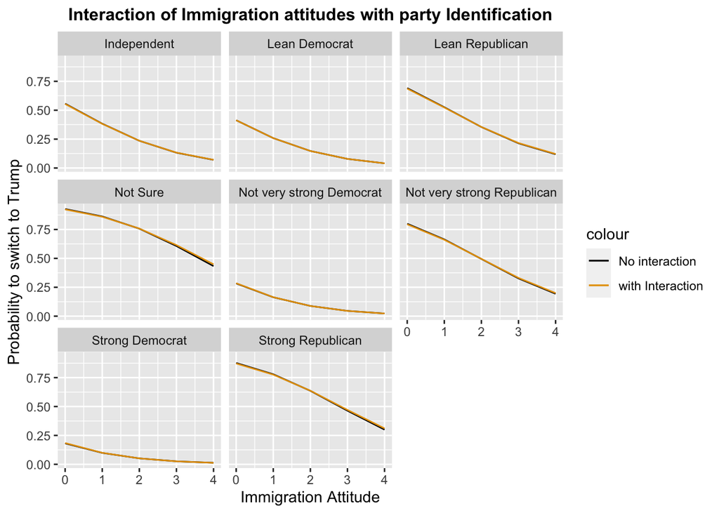

```r
#For party Identification
#1. With No interactions for Party Identification demographic variable

pid.logit=glm(isTrump~ pro.img + pid7_num,family="binomial",data=obama,weights = obama$commonweight_vv_post)
pid.df=expand.grid(pro.img=0:4,pid7_num=c(1,2,3,4,5,6,7,8))
pid.nointer.pred=predict(pid.logit,newdata = pid.df,type = "response")
pid.nointer.pred=as.vector((pid.nointer.pred))

#2. With interaction for Education demographic variable
pid.logit.inter=glm(isTrump~pro.img*pid7_num,family = "binomial",data=obama,weights = obama$commonweight_vv_post)
pid.inter.pred=predict(pid.logit.inter,type = "response",newdata = pid.df)
pid.inter.pred=as.vector((pid.inter.pred))

#Forming a new data frame
pid.pred.df=data.frame(pid.df,pid.nointer.pred,pid.inter.pred)
pid.pred.df = pid.pred.df %>% mutate(pid7= recode(pid7_num,'1'= 'Strong Democrat', '2'='Not very strong Democrat' ,'7'='Strong Republican', '6'='Not very strong Republican','3'= 'Lean Democrat','5'='Lean Republican','4'='Independent','8'='Not Sure', ' 0' ='Not Sure'))
#Ggplot
ggplot(pid.pred.df,aes(x=pid.pred.df$pro.img))+geom_line(aes(y=pid.pred.df$pid.nointer.pred,color="No interaction"))+geom_line(aes(y=pid.pred.df$pid.inter.pred,color="with Interaction"))+facet_wrap(~pid.pred.df$pid7)+ylab("Probability to switch to Trump")+xlab("Immigration Attitude")+ggtitle("Interaction of Immigration attitudes with party Identification") + theme(plot.title = element_text(size = 12, face = "bold", hjust = 0.5)) + scale_colour_manual(values=cbPalette)
```

From the above visualizations we can say that race and education show a slight differences in probabilities when compared with models with and without interaction,where as the gender and party identification don’t show any changes in probabilities by model with and without interaction

### Question 3

```r
model1.logit=glm(isTrump~ pid7_num+ educ_num + race_num + gender_num ,family="binomial",data=obama,weights = obama$commonweight_vv_post)
summary(model1.logit)
```

```
##
## Call:
## glm(formula = isTrump ~ pid7_num + educ_num + race_num + gender_num,
##     family = "binomial", data = obama, weights = obama$commonweight_vv_post)
##
## Deviance Residuals:
##     Min       1Q   Median       3Q      Max
## -5.5957  -0.3797  -0.2446  -0.1653   9.5497
##
## Coefficients:
##             Estimate Std. Error z value Pr(>|z|)
## (Intercept) -2.93662    0.07613 -38.574  < 2e-16 ***
## pid7_num     0.64952    0.01392  46.651  < 2e-16 ***
## educ_num    -0.19474    0.01645 -11.835  < 2e-16 ***
## race_num    -0.31425    0.03114 -10.091  < 2e-16 ***
## gender_num  -0.19025    0.04855  -3.919 8.89e-05 ***
## ---
## Signif. codes:  0 '***' 0.001 '**' 0.01 '*' 0.05 '.' 0.1 ' ' 1
##
## (Dispersion parameter for binomial family taken to be 1)
##
##     Null deviance: 14691  on 23376  degrees of freedom
## Residual deviance: 11944  on 23372  degrees of freedom
##   (18 observations deleted due to missingness)
## AIC: 12224
##
## Number of Fisher Scoring iterations: 5
```

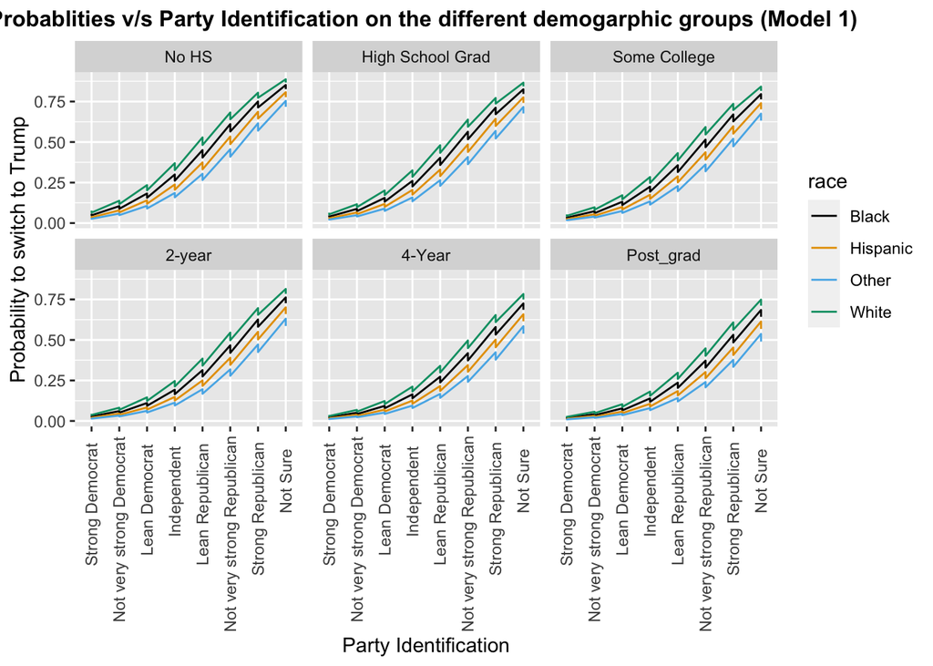

```r
#Forming a new data frame for model 1 (without the Immigration attitude)
Logit.model1.df=expand.grid(pid7_num=c(1,2,3,4,5,6,7,8), educ_num=c(1,2,3,4,5,6), race_num=c(0,1,2,3), gender_num=c(0,1))

#prediction of model 1 on the new data frame (generating switching to probabilities)
noimmigration.pred=predict(model1.logit,newdata = Logit.model1.df,type = "response")
noimmigration.pred=as.vector((noimmigration.pred))
model1.pred.df=data.frame(Logit.model1.df,noimmigration.pred)

#Re-coding the values to numerical values to there categories

model1.pred.df = model1.pred.df %>% mutate(educ = recode(educ_num,'1'='No HS', '2'='High School Grad','3'='Some College', '4'='2-year' , '5'= '4-Year','6'= 'Post_grad'))
model1.pred.df = model1.pred.df %>% mutate(race = recode(race_num,'0'='White', '1'='Black','2'='Hispanic', '3'='Other'))
model1.pred.df = model1.pred.df %>% mutate(pid7= recode(pid7_num,'1'= 'Strong Democrat', '2'='Not very strong Democrat' ,'3'= 'Lean Democrat','4'='Independent','5'='Lean Republican','6'='Not very strong Republican','7'='Strong Republican', '8'='Not Sure'))

model1.pred.df$educ <- as.character(model1.pred.df$educ)
model1.pred.df$educ <- factor(model1.pred.df$educ, levels= c('No HS', 'High School Grad','Some College', '2-year' , '4-Year','Post_grad'))

model1.pred.df$pid7 <- as.character(model1.pred.df$pid7)
model1.pred.df$pid7 <- factor(model1.pred.df$pid7, levels= c('Strong Democrat', 'Not very strong Democrat' ,'Lean Democrat','Independent','Lean Republican','Not very strong Republican','Strong Republican', 'Not Sure'))

#GGplot

ggplot(model1.pred.df, aes(x = factor(pid7,c('Strong Democrat', 'Not very strong Democrat' ,'Lean Democrat','Independent','Lean Republican','Not very strong Republican','Strong Republican', 'Not Sure')), y = noimmigration.pred, color = race, group = race)) + facet_wrap(~educ)  + theme(axis.text.x = element_text(angle = 90, hjust = .9, vjust = .5)) +geom_line() + ylab("Probability to switch to Trump")+xlab("Party Identification")+ggtitle("Probablities v/s Party Identification on the different demogarphic groups (Model 1) ") + theme(plot.title = element_text(size = 12, face = "bold", hjust = 0.5))+ scale_colour_manual(values=cbPalette)
```

#### Model 2 with immigration attitude as one of the predictor and necessary interractions

```r
model2.logit=glm(isTrump~pro.img + pro.img:educ_num +pid7_num+pro.img:race_num+gender_num,family="binomial",data=obama,weights = obama$commonweight_vv_post)
summary(model2.logit)
```

```
##
## Call:
## glm(formula = isTrump ~ pro.img + pro.img:educ_num + pid7_num +
##     pro.img:race_num + gender_num, family = "binomial", data = obama,
##     weights = obama$commonweight_vv_post)
##
## Deviance Residuals:
##     Min       1Q   Median       3Q      Max
## -6.0964  -0.3396  -0.1913  -0.1095  10.1653
##
## Coefficients:
##                  Estimate Std. Error z value Pr(>|z|)
## (Intercept)      -1.99743    0.06775 -29.482  < 2e-16 ***
## pro.img          -0.43085    0.03282 -13.128  < 2e-16 ***
## pid7_num          0.57563    0.01458  39.477  < 2e-16 ***
## gender_num       -0.17933    0.05106  -3.512 0.000445 ***
## pro.img:educ_num -0.06517    0.00774  -8.420  < 2e-16 ***
## pro.img:race_num -0.10219    0.01501  -6.809  9.8e-12 ***
## ---
## Signif. codes:  0 '***' 0.001 '**' 0.01 '*' 0.05 '.' 0.1 ' ' 1
##
## (Dispersion parameter for binomial family taken to be 1)
##
##     Null deviance: 14691  on 23376  degrees of freedom
## Residual deviance: 10690  on 23371  degrees of freedom
##   (18 observations deleted due to missingness)
## AIC: 10924
##
## Number of Fisher Scoring iterations: 6
```

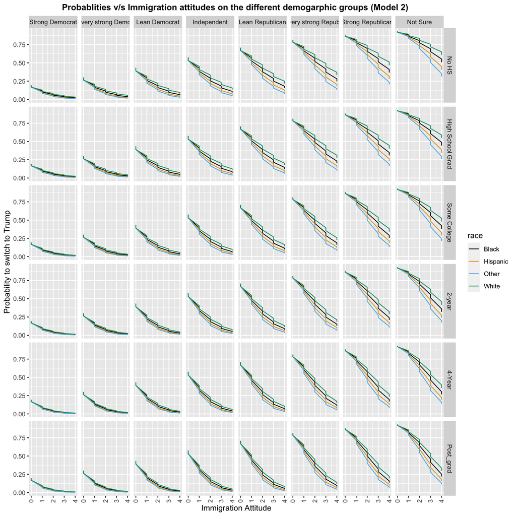

```r
#Forming a new data frame for model 2 (with the Immigration attitude)

Logit.model2.df=expand.grid(pid7_num=c(1,2,3,4,5,6,7,8), educ_num=c(1,2,3,4,5,6), pro.img=0:4,race_num=c(0,1,2,3), gender_num=c(0,1))

#Prediction of model 2 on the new data frame (generating switching to probabilities)
immigration.pred= predict(model2.logit,newdata = Logit.model2.df,type = "response")
immigration.pred=as.vector((immigration.pred))
model2.pred.df=data.frame(Logit.model2.df,immigration.pred)

#Re-coding the values to numerical values to there categories
model2.pred.df = model2.pred.df %>% mutate(educ = recode(educ_num,'1'='No HS', '2'='High School Grad','3'='Some College', '4'='2-year' , '5'= '4-Year','6'= 'Post_grad'))
model2.pred.df = model2.pred.df %>% mutate(race = recode(race_num,'0'='White', '1'='Black','2'='Hispanic', '3'='Other'))
model2.pred.df = model2.pred.df %>% mutate(pid7= recode(pid7_num,'1'= 'Strong Democrat', '2'='Not very strong Democrat' ,'3'= 'Lean Democrat','4'='Independent','5'='Lean Republican','6'='Not very strong Republican','7'='Strong Republican', '8'='Not Sure' ))

model2.pred.df$educ <- as.character(model2.pred.df$educ)
model2.pred.df$educ <- factor(model2.pred.df$educ, levels= c('No HS', 'High School Grad','Some College', '2-year' , '4-Year','Post_grad'))

model2.pred.df$pid7 <- as.character(model2.pred.df$pid7)
model2.pred.df$pid7 <- factor(model2.pred.df$pid7, levels= c('Strong Democrat', 'Not very strong Democrat' ,'Lean Democrat','Independent','Lean Republican','Not very strong Republican','Strong Republican', 'Not Sure'))

#GGplot

ggplot(model2.pred.df, aes(x = pro.img, y =immigration.pred, color = race)) + facet_grid(educ ~pid7,scales='free_x', space='free_x') + geom_line() + theme(axis.text.x = element_text(angle = 90, hjust = .9, vjust = .5))+ ylab("Probability to switch to Trump")+xlab("Immigration Attitude")+ggtitle("Probablities v/s Immigration attitudes on the different demogarphic groups (Model 2) ") + theme(plot.title = element_text(size = 12, face = "bold", hjust = 0.5)) + scale_colour_manual(values=cbPalette)
```

when we compare both the models and plot the probabilities we find substantive differences with and without immigration attitude, for model 1 where immigration attitude is not considered ,we see increasing probabilities as we move towards strong republicans closing towards 0.75 ,with White race being the one with higher probabilities.But when we introduce immigration attitude we see decreasing trend even with strong republicans that is, as immigration attitude increases the probability for switching to trump decreases, even for the white race its the same trend, comparatively No High school demographic shows higher probability when compared with other education levels , the same can be observed with white race , the probabilities switching to trump for white is a bit high when compared with other races , but over all it is decreasing trend in probablities when immigration attitude is considered.